# R Notebook

The Dataset This dataset is a collection of samples obtained from the National Institute of Diabetes and Digestive and Kidney Disease. The goal is to predict whether an individual has diabetes or not.

```r
# load the dataset
read.csv("PimaIndiansDiabetes.csv")-> DF
head(DF)
```

|  | Pregnancies | Glucose | BloodPressure | SkinThickness | Insulin | BMI | DiabetesPedigreeFunction | Age | Outcome |
| --- | --- | --- | --- | --- | --- | --- | --- | --- | --- |
| 1 | 6 | 148 | 72 | 35 | 0 | 33.6 | 0.627 | 50 | 1 |
| 2 | 1 | 85 | 66 | 29 | 0 | 26.6 | 0.351 | 31 | 0 |
| 3 | 8 | 183 | 64 | 0 | 0 | 23.3 | 0.672 | 32 | 1 |
| 4 | 1 | 89 | 66 | 23 | 94 | 28.1 | 0.167 | 21 | 0 |
| 5 | 0 | 137 | 40 | 35 | 168 | 43.1 | 2.288 | 33 | 1 |
| 6 | 5 | 116 | 74 | 0 | 0 | 25.6 | 0.201 | 30 | 0 |

Q1: Which variables are numeric and which are categorical? Explain why. (20pts) Make sure to convert the variables to the correct type.

```r
summary(DF)
```

```
##   Pregnancies        Glucose      BloodPressure    SkinThickness
##  Min.   : 0.000   Min.   :  0.0   Min.   :  0.00   Min.   : 0.00
##  1st Qu.: 1.000   1st Qu.: 99.0   1st Qu.: 62.00   1st Qu.: 0.00
##  Median : 3.000   Median :117.0   Median : 72.00   Median :23.00
##  Mean   : 3.845   Mean   :120.9   Mean   : 69.11   Mean   :20.54
##  3rd Qu.: 6.000   3rd Qu.:140.2   3rd Qu.: 80.00   3rd Qu.:32.00
##  Max.   :17.000   Max.   :199.0   Max.   :122.00   Max.   :99.00
##     Insulin           BMI        DiabetesPedigreeFunction      Age
##  Min.   :  0.0   Min.   : 0.00   Min.   :0.0780           Min.   :21.00
##  1st Qu.:  0.0   1st Qu.:27.30   1st Qu.:0.2437           1st Qu.:24.00
##  Median : 30.5   Median :32.00   Median :0.3725           Median :29.00
##  Mean   : 79.8   Mean   :31.99   Mean   :0.4719           Mean   :33.24
##  3rd Qu.:127.2   3rd Qu.:36.60   3rd Qu.:0.6262           3rd Qu.:41.00
##  Max.   :846.0   Max.   :67.10   Max.   :2.4200           Max.   :81.00
##     Outcome
##  Min.   :0.000
##  1st Qu.:0.000
##  Median :0.000
##  Mean   :0.349
##  3rd Qu.:1.000
##  Max.   :1.000
```

```r
str(DF)
```

```
## 'data.frame':    768 obs. of  9 variables:
##  $ Pregnancies             : int  6 1 8 1 0 5 3 10 2 8 ...
##  $ Glucose                 : int  148 85 183 89 137 116 78 115 197 125 ...
##  $ BloodPressure           : int  72 66 64 66 40 74 50 0 70 96 ...
##  $ SkinThickness           : int  35 29 0 23 35 0 32 0 45 0 ...
##  $ Insulin                 : int  0 0 0 94 168 0 88 0 543 0 ...
##  $ BMI                     : num  33.6 26.6 23.3 28.1 43.1 25.6 31 35.3 30.5 0 ...
##  $ DiabetesPedigreeFunction: num  0.627 0.351 0.672 0.167 2.288 ...
##  $ Age                     : int  50 31 32 21 33 30 26 29 53 54 ...
##  $ Outcome                 : int  1 0 1 0 1 0 1 0 1 1 ...
```

*Variable Type:-* 1. *Categorical:* Outcome is a categorical variable. It is categorized into two groups 0 and 1. 0 indicates “without diabetes” and 1 indicating “with diabetes”.

2. *Numerical:* Pregnancies, Glucose, Blood pressure, Skin thickness, Insulin, BMI, DiabetesPedigreeFunction and Age are continuous numerical variables. All these variables show quantitative data that could be measured. Pregnancies and Age are discrete numerical variables, their value always has to be positive integers, making them “discrete”. All other numerical values are continous and they can have infinite number of possible values.

```r
# converting the variables outcome as a factor and other variables as numeric
DF$Outcome <- as.factor(DF$Outcome)
DF$Pregnancies <- as.numeric(DF$Pregnancies)
DF$Glucose <- as.numeric(DF$Glucose)
DF$BloodPressure <- as.numeric(DF$BloodPressure)
DF$SkinThickness <- as.numeric(DF$SkinThickness)
DF$Insulin <- as.numeric(DF$Insulin)
DF$Age <- as.numeric(DF$Age)
```

```r
str(DF)
```

```
## 'data.frame':    768 obs. of  9 variables:
##  $ Pregnancies             : num  6 1 8 1 0 5 3 10 2 8 ...
##  $ Glucose                 : num  148 85 183 89 137 116 78 115 197 125 ...
##  $ BloodPressure           : num  72 66 64 66 40 74 50 0 70 96 ...
##  $ SkinThickness           : num  35 29 0 23 35 0 32 0 45 0 ...
##  $ Insulin                 : num  0 0 0 94 168 0 88 0 543 0 ...
##  $ BMI                     : num  33.6 26.6 23.3 28.1 43.1 25.6 31 35.3 30.5 0 ...
##  $ DiabetesPedigreeFunction: num  0.627 0.351 0.672 0.167 2.288 ...
##  $ Age                     : num  50 31 32 21 33 30 26 29 53 54 ...
##  $ Outcome                 : Factor w/ 2 levels "0","1": 2 1 2 1 2 1 2 1 2 2 ...
```

Q2: Use appropriate statistical analysis to determine which of the variables ( on their own ) are most helpful in predicting the outcome? (20pts) For each variable draw an appropriate graph ( boxplot for numerical values and barplot for categorical values). Explain your answer.

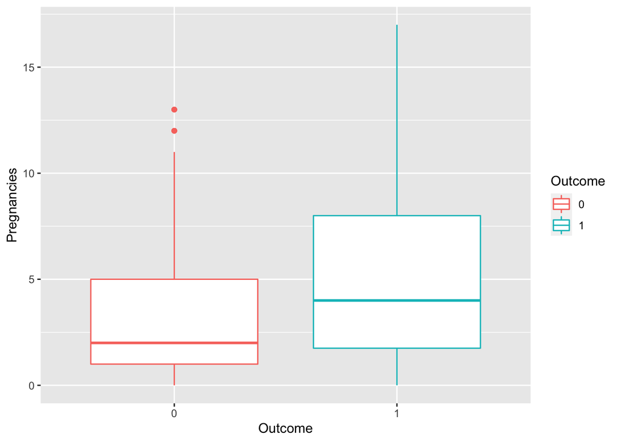

```r
library(ggplot2) # using the library ggplot for creating box plot
# box plot for Pregnancies
box_plot1 <- ggplot(DF, aes(x = Outcome, y = Pregnancies, color = Outcome))
box_plot1 +
    geom_boxplot()
```

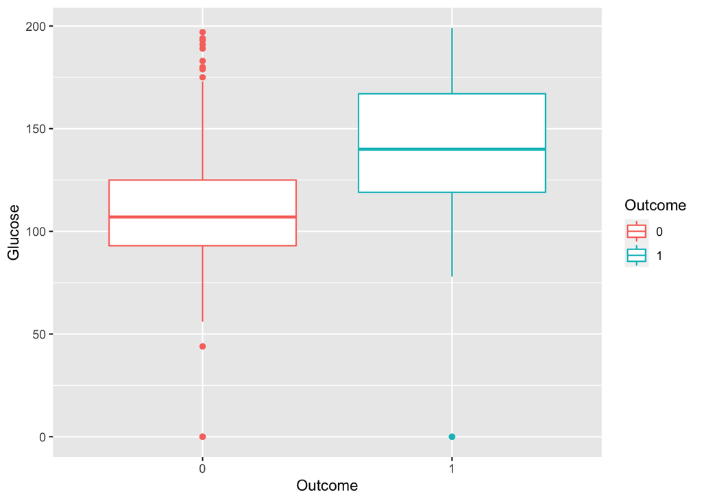

```r
# box plot for Glucose
box_plot2 <- ggplot(DF, aes(x = Outcome, y = Glucose, color = Outcome))
box_plot2 +
    geom_boxplot()
```

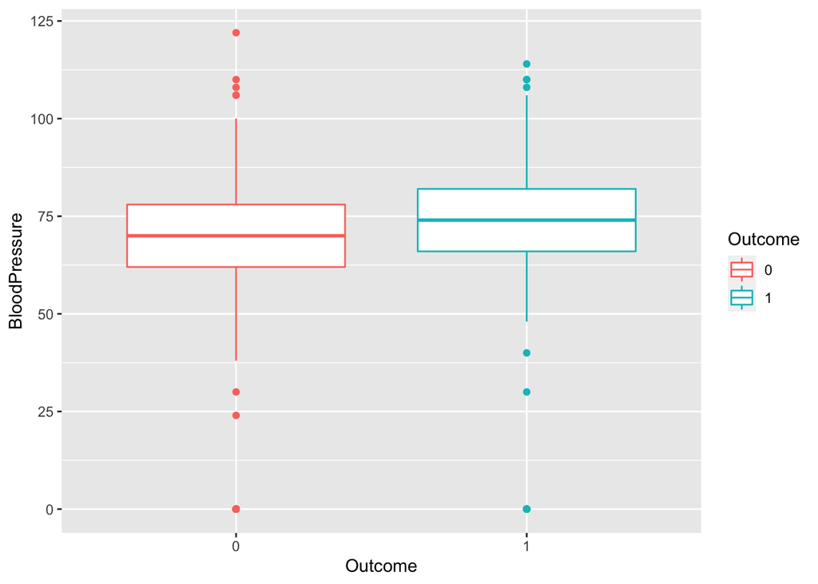

```r
# box plot for BloodPressure
box_plot3 <- ggplot(DF, aes(x = Outcome, y = BloodPressure, color = Outcome))
box_plot3 +
    geom_boxplot()
```

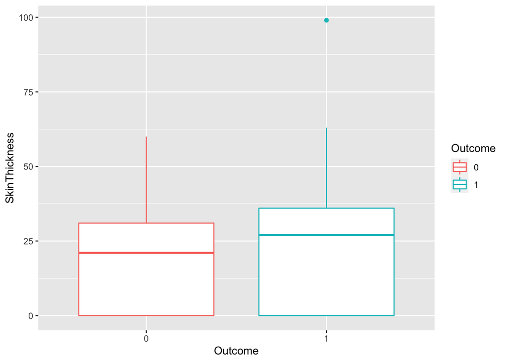

```r
# box plot for SkinThickness
box_plot4 <- ggplot(DF, aes(x = Outcome, y = SkinThickness, color = Outcome))
box_plot4 +
    geom_boxplot()
```

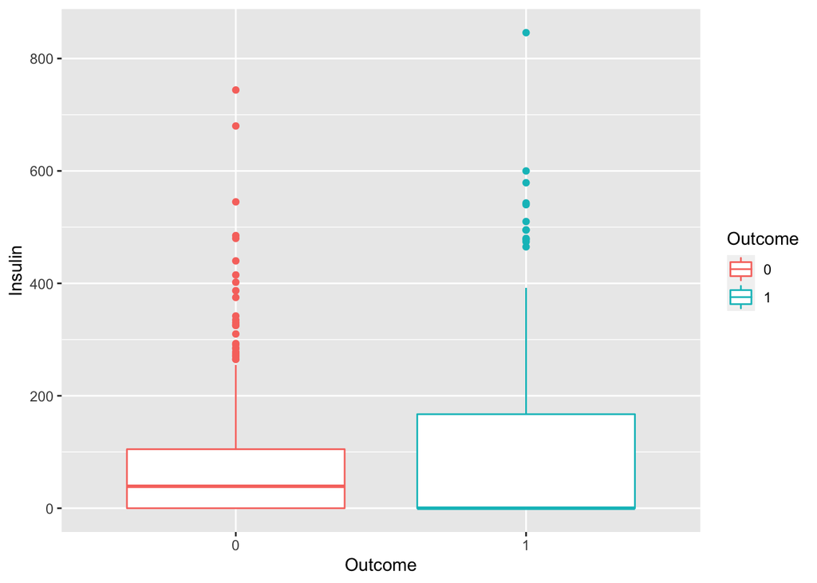

```r
# box plot for Insulin
box_plot5 <- ggplot(DF, aes(x = Outcome, y = Insulin, color = Outcome))
box_plot5 +
    geom_boxplot()
```

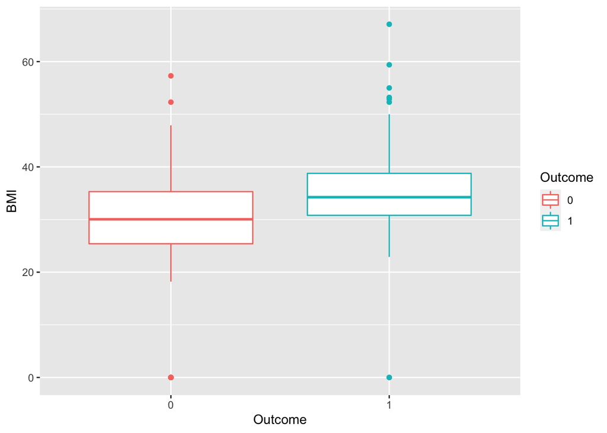

```r
# box plot for BMI
box_plot6 <- ggplot(DF, aes(x = Outcome, y = BMI, color = Outcome))
box_plot6 +
    geom_boxplot()
```

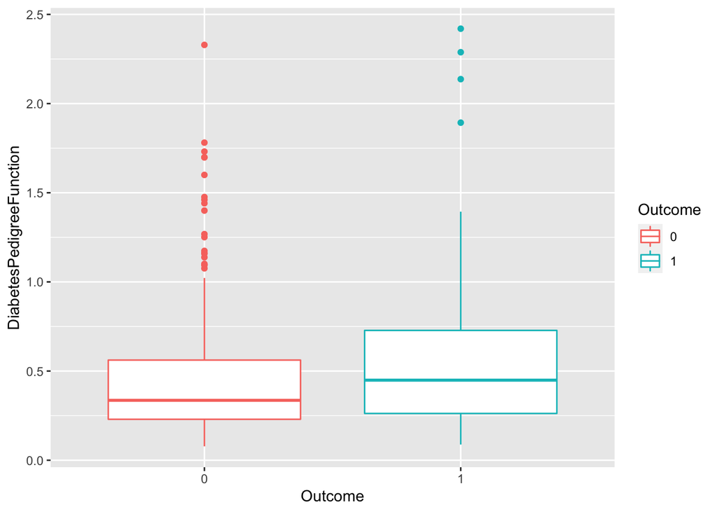

```r
# box plot for DiabetesPedigreeFunction
box_plot7 <- ggplot(DF, aes(x = Outcome, y = DiabetesPedigreeFunction, color = Outcome))
box_plot7 +
    geom_boxplot()
```

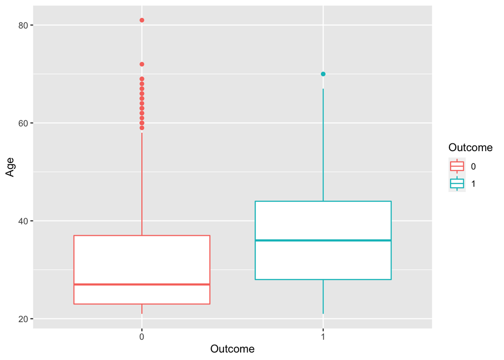

```r
# box plot for Age
box_plot8 <- ggplot(DF, aes(x = Outcome, y = Age, color = Outcome))
box_plot8 +
    geom_boxplot()
```

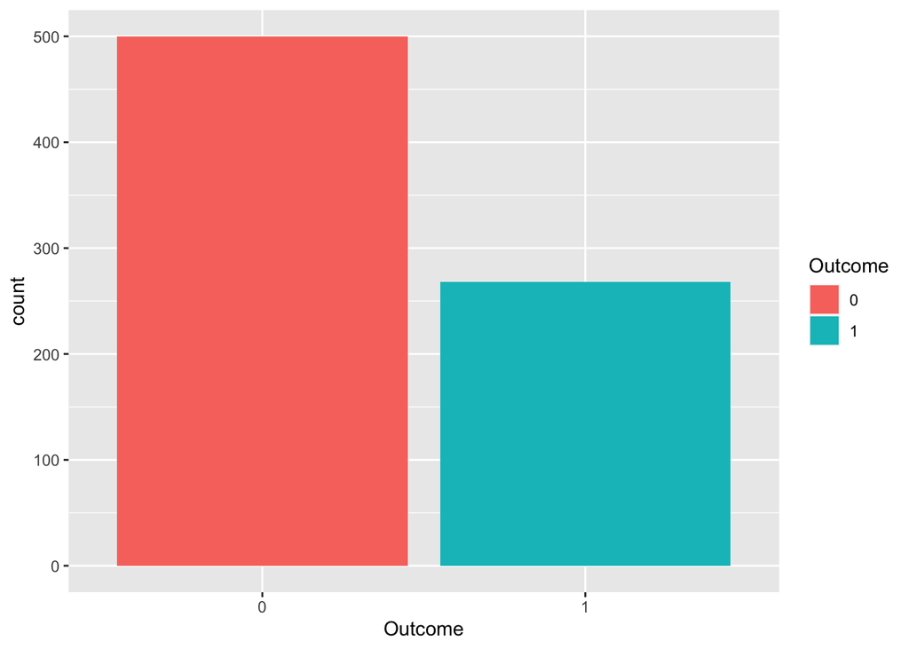

```r
# bar plot for Outcome
bar_plot_Outcome <- ggplot(data = DF, aes(x=Outcome, fill= Outcome))+ geom_bar(stat="count")
bar_plot_Outcome
```

```r
library(randomForest)
```

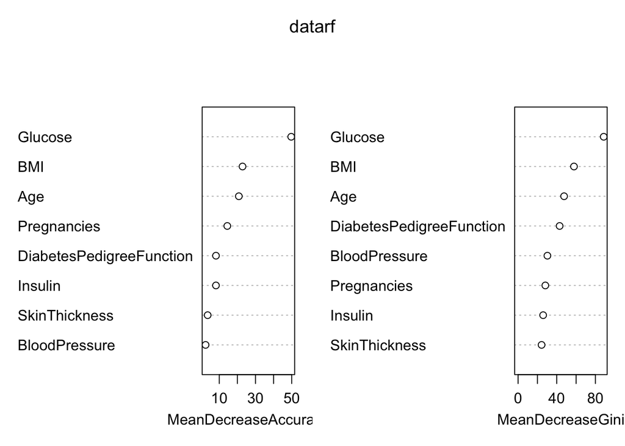

```r
# To identify the most important variable, using random forests
datarf = randomForest(Outcome ~ ., data=DF, importance=T)
varImpPlot(datarf)
```

#

**ANSWER:** Glucose seems to be the most important variable

```r
# To identify the most important variable, we will perform a logitical regression
LR_impVariable <- glm(Outcome ~ Pregnancies + Glucose + BloodPressure + SkinThickness + Insulin + BMI+ DiabetesPedigreeFunction + Age, data = DF, family = binomial)
coef(LR_impVariable)
```

```
##              (Intercept)              Pregnancies                  Glucose
##            -8.4046963669             0.1231822984             0.0351637146
##            BloodPressure            SkinThickness                  Insulin
##            -0.0132955469             0.0006189644            -0.0011916990
##                      BMI DiabetesPedigreeFunction                      Age
##             0.0897009700             0.9451797406             0.0148690047
```

```r
#summary(LR_impVariable)
```

```r
# Performing ANOVA Chi-square test to check the overall effect of variables
anova(LR_impVariable, test = "Chisq")
```

|  | Df | Deviance | Resid. Df | Resid. Dev | Pr(>Chi) |
| --- | --- | --- | --- | --- | --- |
| NULL | NA | NA | 767 | 993.4839 | NA |
| Pregnancies | 1 | 37.2740265 | 766 | 956.2099 | 1.026426e-09 |
| Glucose | 1 | 171.2598993 | 765 | 784.9500 | 3.926429e-39 |
| BloodPressure | 1 | 0.8879193 | 764 | 784.0621 | 3.460418e-01 |
| SkinThickness | 1 | 3.9992262 | 763 | 780.0628 | 4.552116e-02 |
| Insulin | 1 | 1.9721388 | 762 | 778.0907 | 1.602210e-01 |
| BMI | 1 | 41.2428182 | 761 | 736.8479 | 1.344449e-10 |
| DiabetesPedigreeFunction | 1 | 10.8802986 | 760 | 725.9676 | 9.719257e-04 |
| Age | 1 | 2.5222056 | 759 | 723.4454 | 1.122535e-01 |

```r
# Compute a correlation matrix
library(corrplot)
DF_cor <- cor(DF[,1:8])
DF_cor
```

```
##                          Pregnancies    Glucose BloodPressure SkinThickness
## Pregnancies               1.00000000 0.12945867    0.14128198   -0.08167177
## Glucose                   0.12945867 1.00000000    0.15258959    0.05732789
## BloodPressure             0.14128198 0.15258959    1.00000000    0.20737054
## SkinThickness            -0.08167177 0.05732789    0.20737054    1.00000000
## Insulin                  -0.07353461 0.33135711    0.08893338    0.43678257
## BMI                       0.01768309 0.22107107    0.28180529    0.39257320
## DiabetesPedigreeFunction -0.03352267 0.13733730    0.04126495    0.18392757
## Age                       0.54434123 0.26351432    0.23952795   -0.11397026
##                              Insulin        BMI DiabetesPedigreeFunction
## Pregnancies              -0.07353461 0.01768309              -0.03352267
## Glucose                   0.33135711 0.22107107               0.13733730
## BloodPressure             0.08893338 0.28180529               0.04126495
## SkinThickness             0.43678257 0.39257320               0.18392757
## Insulin                   1.00000000 0.19785906               0.18507093
## BMI                       0.19785906 1.00000000               0.14064695
## DiabetesPedigreeFunction  0.18507093 0.14064695               1.00000000
## Age                      -0.04216295 0.03624187               0.03356131
##                                  Age
## Pregnancies               0.54434123
## Glucose                   0.26351432
## BloodPressure             0.23952795
## SkinThickness            -0.11397026
## Insulin                  -0.04216295
## BMI                       0.03624187
## DiabetesPedigreeFunction  0.03356131
## Age                       1.00000000
```

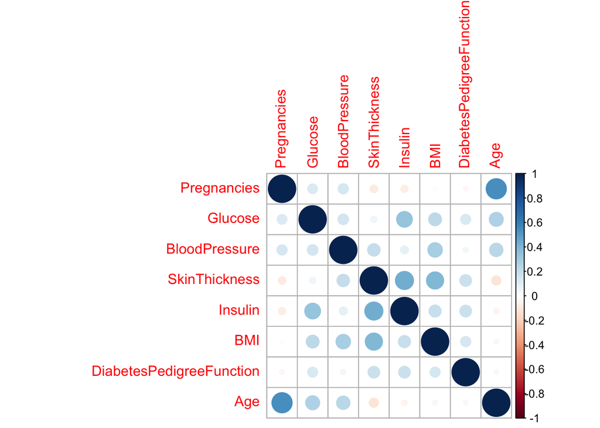

```r
corrplot(DF_cor)
```

```r
#Building a new model by removing the less significant variables to achieve a lower AIC value
LR_impVariable_new <- glm(Outcome ~ Pregnancies + Glucose + BMI + DiabetesPedigreeFunction + BloodPressure, data = DF, family = binomial)
summary(LR_impVariable_new)
```

```
##
## Call:
## glm(formula = Outcome ~ Pregnancies + Glucose + BMI + DiabetesPedigreeFunction +
##     BloodPressure, family = binomial, data = DF)
##
## Deviance Residuals:
##     Min       1Q   Median       3Q      Max
## -2.7931  -0.7362  -0.4188   0.7251   2.9555
##
## Coefficients:
##                           Estimate Std. Error z value Pr(>|z|)
## (Intercept)              -7.954952   0.675823 -11.771  < 2e-16 ***
## Pregnancies               0.153492   0.027835   5.514  3.5e-08 ***
## Glucose                   0.034658   0.003394  10.213  < 2e-16 ***
## BMI                       0.084832   0.014125   6.006  1.9e-09 ***
## DiabetesPedigreeFunction  0.910628   0.294027   3.097  0.00195 **
## BloodPressure            -0.012007   0.005031  -2.387  0.01700 *
## ---
## Signif. codes:  0 '***' 0.001 '**' 0.01 '*' 0.05 '.' 0.1 ' ' 1
##
## (Dispersion parameter for binomial family taken to be 1)
##
##     Null deviance: 993.48  on 767  degrees of freedom
## Residual deviance: 728.56  on 762  degrees of freedom
## AIC: 740.56
##
## Number of Fisher Scoring iterations: 5
```

```r
anova(LR_impVariable, LR_impVariable_new, test = "Chisq")
```

|  | Resid. Df | Resid. Dev | Df | Deviance | Pr(>Chi) |
| --- | --- | --- | --- | --- | --- |
| 1 | 759 | 723.4454 | NA | NA | NA |
| 2 | 762 | 728.5596 | -3 | -5.114228 | 0.1636214 |

The new model has a AIC value less than the original one (740.56 < 741.45) representing a better model **ANSWER:** Glucose is the most important variable

Q3: Are there any missing values? and how do we fix this ? (20pts) Notice that some of the values are missing and replaced with 0. For example a blood pressure of 0 doesn’t make sense and it can have an impact on the models. So how do we identify which 0 represents the value 0 and which represents NA? Explain your answer.

```r
sapply(DF, function(x) sum(is.na(x)))
```

```
##              Pregnancies                  Glucose            BloodPressure
##                        0                        0                        0
##            SkinThickness                  Insulin                      BMI
##                        0                        0                        0
## DiabetesPedigreeFunction                      Age                  Outcome
##                        0                        0                        0
```

```r
which(DF$Pregnancies == 0) # Number of pregnancies can be zero, so assuming that there is no missing data in the Pregnancy column
```

```
##   [1]   5  17  46  58  59  60  67  79  84 103 110 121 125 130 137 138 139 146
##  [19] 163 165 178 182 201 203 212 214 221 227 230 238 240 248 254 267 269 278
##  [37] 281 291 292 295 298 301 308 309 312 323 336 337 368 372 373 377 380 382
##  [55] 398 408 415 423 427 429 436 441 446 448 449 450 453 466 467 468 472 473
##  [73] 476 482 484 485 486 488 507 512 529 530 532 537 538 539 562 565 570 581
##  [91] 590 596 597 609 620 624 627 628 632 641 648 650 678 682 683 698 714 728
## [109] 737 754 758
```

```r
# Substituting the missing values by replacing them with mean values

#which(DF$Glucose == 0) # Glucose can't be 0 and has to be replaced
DF[which(DF$Glucose == 0),"Glucose"] <- mean(DF$Glucose)
```

```r
# Substituting the missing values by replacing them with mean values

#which(DF$BloodPressure == 0) # BloodPressure can't be 0 and has to be replaced
DF[which(DF$BloodPressure == 0),"BloodPressure"] <- mean(DF$BloodPressure)
```

```r
# Substituting the missing values by replacing them with mean values

#which(DF$SkinThickness == 0) # Skin thickness is not possible to be 0 and has to be replaced
DF[which(DF$SkinThickness == 0),"SkinThickness"] <- mean(DF[which(DF$SkinThickness != 0),"SkinThickness"]) # We replace missing data with the average of non-zero value because too much 0's will affect the average calculation
```

```r
# Substituting the missing values by replacing them with mean values

#which(DF$Insulin == 0) # Insulin can't be 0 and has to be replaced
DF[which(DF$Insulin == 0),"Insulin"] <- mean(DF[which(DF$Insulin != 0),"Insulin"])
```

```r
# Substituting the missing values by replacing them with mean values

#which(DF$BMI == 0) #BMI can't be 0 and has to be replaced
DF[which(DF$BMI == 0),"BMI"] <- mean(DF$BMI)
```

```r
which(DF$DiabetesPedigreeFunctions == 0) # no missing values in DiabetesPedigreeFunction
```

```
## integer(0)
```

```r
which(DF$Age == 0) # no missing values in Age
```

```
## integer(0)
```

Q4: Building the Model (20pts) · You are free to use either : leave out 30% or 10xfold Cross Validation for your testing purpose. · You may pick any of the following to perform your modeling ( randomForest, SVM, KNN, or neural nets) · Explain your approach ( for example, if you are only picking one, why did you pick it? if you are going to do all, how will you decide which is best?)

**Answer:** Using the leave out 30% test method for all the 4 models to determine the best model

```r
Negative = DF[which(DF[,"Outcome"] == "0"),]
Positive = DF[which(DF[,"Outcome"] == "1"),]

sample(1:nrow(Negative), nrow(Positive))->rand.0
Negative[rand.0,]-> Negative_test
Positive-> Positive_test
```

```r
set.seed(500)
#splitting the data which contains outcome =1 (have diabetes) as training set (70%) and test set (30%)
split_Positive<-sample(nrow(Positive_test), floor(nrow(Positive_test) * 0.7))
split.train_Positive <- Positive_test[split_Positive,]
split.test_Positive <- Positive_test[-split_Positive,]
```

```r
set.seed(500)
#splitting the data which contains outcome = 0 (no diabetes) as training set (70%) and test set (30%)
split_Negative<-sample(nrow(Negative_test), floor(nrow(Negative_test) * 0.7))
split.train_Negative <- Negative_test[split_Negative,]
split.test_Negative <- Negative_test[-split_Negative,]
```

```r
split.test <- rbind(split.test_Positive, split.test_Negative)
table(split.test[, "Outcome"])
```

```
##
##  0  1
## 81 81
```

```r
split.train <- rbind(split.train_Positive, split.train_Negative)
table(split.train[, "Outcome"])
```

```
##
##   0   1
## 187 187
```

#### Random Forest Model

```r
library("AUC")
randomforest_auc <- c()

for(i in 1:8){
    rf <- randomForest(Outcome ~ ., data = split.train,ntree=100,mtry = i,importance=TRUE)
    prob <- predict(rf, newdata = split.test,type="prob")[,2]
    randomforest_auc <- c(randomforest_auc,auc(roc(prob, split.test$Outcome)))
}
print(randomforest_auc)
```

```
## [1] 0.7926383 0.8029264 0.7890565 0.7966773 0.7917238 0.7873038 0.7818930
## [8] 0.7817406
```

#### KNN Model

```r
# Scaling the test and training sets
scaled_testData <- as.data.frame(scale(split.test[,1:8]))
scaled_trainData <- as.data.frame(scale(split.train[,1:8]))
```

```r
# To Calculate the AUC values of  KNN models using a for loop
library("class")

KNN_AUC<-function(n){
  out<-matrix(data=NA, nrow = 1, ncol = n)
  rownames(out)<-c("AUC")
  for (i in 1:n){
  data.knn.prob = knn(scaled_trainData, scaled_testData, split.train$Outcome,k=i,prob = TRUE)
  diagnosis_test=which(data.knn.prob==0)
  attr(data.knn.prob,"prob")[diagnosis_test] = 1-attr(data.knn.prob,"prob")[diagnosis_test]
  data.knn.prob_roc <- roc(attr(data.knn.prob,"prob"),split.test$Outcome)
  out[,i]=auc(data.knn.prob_roc)
  }
  return(out)
}
```

```r
KNN_AUC(30) # to print the AUC values of first 30 k values
```

```
##         [,1]      [,2]     [,3]      [,4]      [,5]      [,6]      [,7]
## AUC 0.654321 0.6912818 0.716659 0.7526292 0.7680232 0.7615455 0.7581923
##          [,8]      [,9]     [,10]   [,11]     [,12]     [,13]     [,14]
## AUC 0.7719098 0.7876086 0.7864655 0.78738 0.7799878 0.7788447 0.7785399
##         [,15]     [,16]     [,17]     [,18]    [,19]     [,20]     [,21]
## AUC 0.7788447 0.7777778 0.7693949 0.7716811 0.772367 0.7785399 0.7712239
##         [,22]     [,23]     [,24]     [,25]     [,26]     [,27]     [,28]
## AUC 0.7757964 0.7685566 0.7751867 0.7754153 0.7733577 0.7719098 0.7774729
##         [,29]     [,30]
## AUC 0.7731291 0.7735863
```

#### SVM Model

```r
scaled_testData$Outcome <- split.test$Outcome
scaled_trainData$Outcome <- split.train$Outcome
scaled_trainData$Outcome <- as.factor(scaled_trainData$Outcome)
scaled_testData$Outcome  <- as.factor(scaled_testData$Outcome)
table(scaled_trainData[,"Outcome"])
```

```
##
##   0   1
## 187 187
```

```r
table(scaled_testData[,"Outcome"])
```

```
##
##  0  1
## 81 81
```

```r
library(e1071)

SVM_AUC <-function(n){
  s <- seq(0.0, n, by = 0.5)
  diab_mat<-matrix(nrow=length(s),ncol=2 )
  for (i in 1:length(s)){
    svm_model = svm(Outcome ~ .,data=scaled_trainData,cost=i,probability=T)
    data_pred= predict(svm_model,scaled_testData, probability=T)
    data_pred_mat=attr(data_pred,"probabilities")

    out<-auc(roc(predictions =data_pred_mat[,"1"],scaled_testData$Outcome))
    diab_mat[i,1]=s[i]
    diab_mat[i,2]=out}
    colnames(diab_mat) <- c("cost","AUC")
  return(diab_mat)
}
```

```r
SVM_AUC(5)
```

```
##       cost       AUC
##  [1,]  0.0 0.8026216
##  [2,]  0.5 0.7977442
##  [3,]  1.0 0.7835696
##  [4,]  1.5 0.7762536
##  [5,]  2.0 0.7703094
##  [6,]  2.5 0.7669563
##  [7,]  3.0 0.7620790
##  [8,]  3.5 0.7611645
##  [9,]  4.0 0.7599451
## [10,]  4.5 0.7600975
## [11,]  5.0 0.7604024
```

#### Neural Network Model

```r
# scale the data first
maxs<-apply(DF[,1:5], 2, max)
mins<-apply(DF[,1:5], 2, min)
scaled.data<-as.data.frame(scale(DF[,1:5],center=mins,scale = maxs-mins))
Outcome<-as.numeric(DF$Outcome) -1
scaled.data.df<-cbind(Outcome,scaled.data)

set.seed(5)

table(scaled.data.df[,"Outcome"])
```

```
##
##   0   1
## 500 268
```

```r
all0<-scaled.data.df[which(scaled.data.df[,"Outcome"] == 0),]
all1<-scaled.data.df[which(scaled.data.df[,"Outcome"] == 1),]

rand.0 <- sample(1:nrow(all0), nrow(all1))
No_diabetes <- all0[rand.0,]
Yes_diabetes <- all1

training.split<-rbind(No_diabetes, Yes_diabetes)
split<-sample(nrow(training.split), floor(nrow(training.split) * 0.7))
data.train<-training.split[split,]
data.test<-training.split[-split,]

table(data.train[,"Outcome"])
```

```
##
##   0   1
## 189 186
```

```r
table(data.test[,"Outcome"])
```

```
##
##  0  1
## 79 82
```

```r
library(neuralnet)

data.nn = neuralnet(Outcome ~ ., data = data.train, hidden=c(5), rep=1, linear.output = F)

data.nn.results = neuralnet::compute(data.nn, data.test[,2:6])

data.nn.roc = roc(data.nn.results$net.result,as.factor(data.test$Outcome))
auc(data.nn.roc)
```

```
## [1] 0.7794072
```

```r
final_auc <- c()

data.test$Outcome <-as.factor(data.test$Outcome)

for (i in c(1:2)){
  data.nn = neuralnet(Outcome ~ ., data=data.train, hidden=c(i), rep=3, linear.output = F)
  data.nn.results = neuralnet::compute(data.nn, data.test[,2:6])
  data.nn.roc = roc(data.nn.results$net.result, data.test$Outcome)
  final_auc[i] <- auc(data.nn.roc)
}
final_auc
```

```
## [1] 0.8274159 0.7803334
```

Q5: The Final Model (20pts) · Determine which model worked the best and why you think so. · Create a plot using colors to show which points are were predicted to have Diabetes and which were not. Use shapes to show which points were actually Diabetes and which weren’t.